# Transit analysis of Kepler data from Unknown Star System

**Candidate number: 25190**

### Abstract:

This investigation attempted to analyse data from the Kepler space telescope to detect habitable Earth sized exoplanets. The primary detection method used was the transit method, in which the exoplanets passed in front of the star and periodic drops in the star’s light were measured, like the Moon blocking out the Sun during a solar eclipse.

Data were analysed from an unknown star system, from which **three exoplanets** were detected, with orbital periods of $(13.024 ± 0.016)$, $(22.687 ± 0.011)$, $(31.996 ± 0.014)$ days respectively. Physical properties of each planet were then extracted, such as their semi-major axes, planetary radii. The masses of the exoplanets were then provided, allowing further calculations of properties such as their mass densities to be carried out. The habitability of each exoplanet was assessed, and it was concluded that these exoplanets are **uninhabitable** for ET life, the main reasons being they're too hot and are not rocky.

A rudimentary transit timing variation (TTV) analysis was attempted. A **new transit detection method** was devised using find_peaks() from SciPy, providing an alternative to folding the lightcurve. Problems were encountered when attempting to sort the transits to each exoplanet. The transit depths were all of similar magnitude, meaning they couldn't be sorted this way. A "looking ahead" algorithm was devised, which had limited success. More knowledge of the star system could allow the TTVs to be simulated. Further observation and a better transit isolating method is needed to accurately plot the exoplanet TTVs, which was not reached due to time limitations.

### 1. Introduction:

#### 1.1 What are exoplanets, and why are they important?

Life is known to have happened once in the whole universe, on one planet Earth. Despite this, scientific discovery from the last century has shown us that besides the existence of life, there is nothing particularly special about our solar system, and that there are many more galaxies out there with their own star systems, some of which contain orbiting gaseous or terrestrial objects that are called exoplanets. Exoplanet detection instrumental in the search from extra-terrestrial life, seeing as multiple terms in Drake’s equation for extra-terrestrial life relate to the frequency and nature of habitable exoplanets in our galaxy (Westby & Conselice, 2020).

Two scientific questions were addressed in this investigation:

- Are the detected exoplanets **habitable**?
- Do they show **periodic** TTVs?

#### 1.2 What is the transit method?

When one puts their hand in front of a a lightbulb it blocks out the incoming light. This can be used to do interesting things like create shadow puppets. It can also be used to detect planets passing in front of far away stars. From the NASA Exoplanet Archive, **92%** of the exoplanets were discovered using the transit detection method, making it by far the most important tool when it comes to searching for ET life.

#### 1.3 What is a habitable exoplanet?

For the purposes of this investigation, a potentially habitable exoplanet is one that is rocky, has an atmosphere and the capacity for liquid water to exist on it. None of these on their own are sufficient to prove that an exoplanet is habitable, but together they are necessary for an exoplanet to house life as we know it.

#### 1.4 What are Transit Timing Variations?

It was decided that Transit Timing Variation (TTV) analysis would also be carried out in this investigation. In a $N$ bodied star system, the force experienced by a single planetary body can be expressed as the sum of the forces that every other body in the system gravitationally exerts on it:

$ \mathbf{F} = G M \sum_{i=1}^{N} \frac{m_i}{\mathbf{r_i}^2} $

The mass of the host star will dominate the gravitational force experienced by the given planet. However, there is a small but finite contribution from the other planets in the system. This leads to the orbit of each planet affecting the orbit of each other planet in the system, and this is measureable by transit timing variations. The time at which a transit occurs will be affected by the positions of the other transits in the system, so a periodic variation in the time at which an exoplanet transits the star should be observed. Mazeh et al. (2013) found that ~ 18% of KOIs (Kepler Objects of Interest) showed significant transit timing variations, and Xie et al. (2018) found that TTV detection rate rises with the number of exoplanets in the system. Since three exoplanets were detected in this system, it was decided that TTV analysis would be carried out. TTVFast as developed by Deck et al. (2014) provides a simulation for computing transit time variations, and could be used to find the TTVs present in this system. However, this code requies knowledge of every object in the system, which is not known. Three exoplanets were discovered, but there could likely be more. Therefore it was decided that the TTVs for each exoplanet would attempted to be plotted to see if any periodicity could be observed.

### 2. Results - Modelling of Kepler lightcurve

#### 2.1 Total lightcurve

Firstly, the Kepler data were reduced, then masked to remove NaNs (Boolean indexing). They were then normalised with median filter (scipy.medfilt). This was used instead of a mean normalisation as this is less susceptible to outliers. Data were then filtered to remove flux above $ \mu + 3\sigma$.

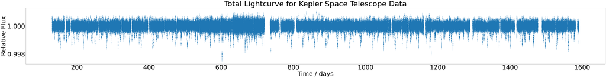

#### 2.2 Periodogram Analysis

Periodogram analysis was carried out on the data. This only returns **potential** exoplanet candidates. Lomb-Scargle periodogram was used (more suitable for unevely sampled data than FFT). lombscargle() was applied twice, once to identify frequencies present, secondly to remove the effects of aliasing. Spikes in the periodogram represent periodic signals found in the total lightcurve.

```
Takes 1m 36s to run natively on my personal computer (M2 Macbook pro), may take longer on Noteable server.

Potential exoplanet periods =  [ 13.02700386  22.69409916  26.04914988  31.99157022  39.0712959
  45.38334048  52.09344192  63.97828261  65.14402057  68.0725818
  78.1661666   90.73339048  91.15987998  95.99342763 104.21045864
 113.4226318  117.23260466 127.98014002 130.25475068 136.11187312
 143.2768967  156.29904272 158.80111444 159.96685241 169.32118874
 181.49035577 182.3717674  191.98199743 195.39391342] days
```

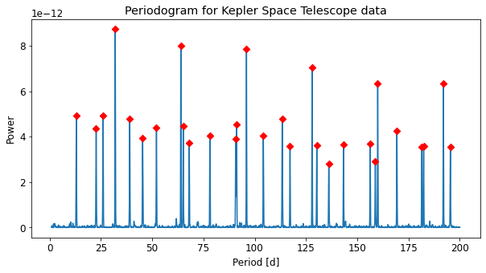

Next, tf.period_finder() was used to extract real exoplanet periods. period_finder() sums up multiples of initial planetary period then divides by the number of multiples. Error is taken as $± \sigma$ of the spread of the given period.

```
Exoplanet period 1 = 13.027 ± 0.016 [days]
Exoplanet period 2 = 22.685 ± 0.011 [days]
Exoplanet period 3 = 32.001 ± 0.014 [days]
```

#### 2.3 Lightcurve folding

The total lightcurve was then folded to periods from period_finder(). The folded lightcurve provides dense lightcurve with overlapping repeated transits. Vicky Scowcroft's function was used to fold lightcurves. Problems now arise as the periods produced by period_finder() don't fold to produce neat lightcurves (shown below). A transit is visible but there is lots of flux data above where the transit is occurring, suggesting the periods determined by period_finder() **aren't accurate enough.**

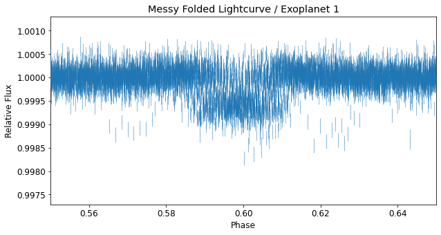

To solve this, a np.linspace() is created spanning the error in each exoplanet orbital period error. The lightcurves are then judged by eye to see which is folded best. This period is taken as the "true" period.

```
Uncheck lines in above code block to plot multiple lightcurves and deduce by eye the best folded lightcurve.
```

```
These are the exoplanet periods as read off from the graphs generated by multiple_lc_plotter:
Exoplanet period 1 = 13.024 ± 0.016 [days]
Exoplanet period 2 = 22.687 ± 0.011 [days]
Exoplanet period 3 = 31.996 ± 0.014 [days]
```

#### 2.4.1 Plotting folded lightcurves with modified Gaussian

The lightcurves for each exoplanet were then folded and plotted. From SciPy, curve_fit() was used to fit a flipped Gaussian model to the data. A Gaussian model was chosen to easily extract transit depth and duration, and the shape fits well to data.

The Gaussian was modified as shown to fit the data:

$f_{(x)} = B - \frac{A}{\sigma \sqrt{2 \pi}} exp(- \frac{1}{2} \frac{(x- \mu)^2}{\sigma^2})$

It was made negative to fit the transits, $A$ and $B$ were introduced to modulate the height and width of the Gaussian.

#### 2.4.2 $\chi^2$, $\chi_r$ calculation

$\chi_r$ is a useful quantity that indicates how well a model fits the data. If $\chi_r$ ~ 1, this indicates the model fits well to the data. It is calculated in a similar way to the residuals of a model.

$\chi^2$ was calculated using the following formula:

$\chi^2 = \sum_{i} \dfrac{(y_i - f(x_i))^2}{\sigma_i^2}$

$\chi_{r}$ can then be calculated as follows:

$\chi_{r} = \dfrac{\chi^2}{\nu-n_{param}-1}$

where $\nu$ is the number of data points and $n_{param}$ is the degrees of freedom of the model.

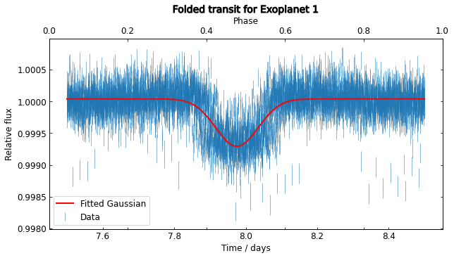

$\displaystyle \chi_r: 6.206919122128631$

```
Time of first transit = 7.9755 ± 0.0011
```

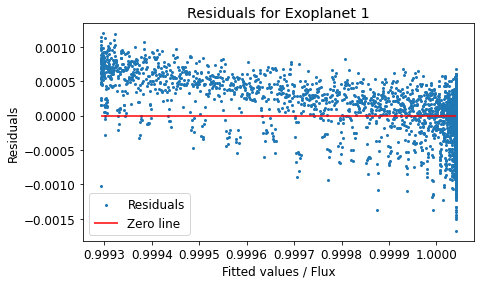

```
Mean of the residuals for Exoplanet 1 = 1.7e-06
------------------------------------------------------------------------------------------------
------------------------------------------------------------------------------------------------
```

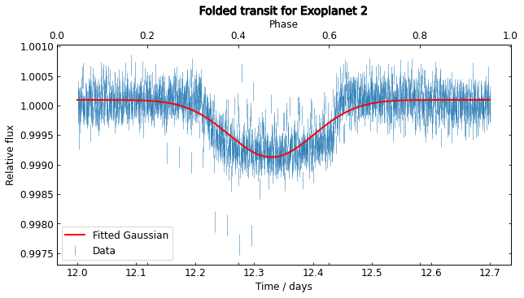

$\displaystyle \chi_r: 11.786526287801669$

```
Time of first transit = 12.3292 ± 0.0013
```

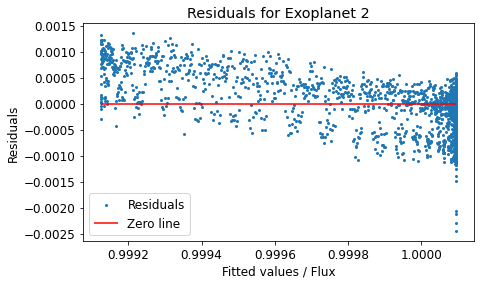

```
Mean of the residuals for Exoplanet 2 = -3.6e-06
------------------------------------------------------------------------------------------------
------------------------------------------------------------------------------------------------
```

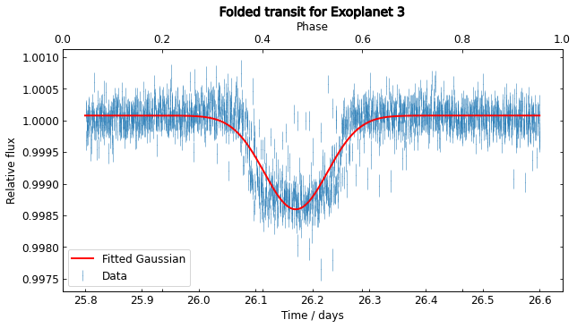

$\displaystyle \chi_r: 20.678376277840627$

```
Time of first transit = 26.1708 ± 0.00098
```

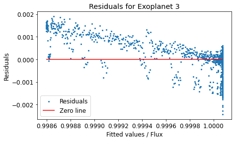

```
Mean of the residuals for Exoplanet 3 = -7.2e-08
------------------------------------------------------------------------------------------------
```

#### 2.5 How well did the Gaussian model fit the data?

The residuals plots show that overall the model fits relatively well to the data. The residuals have a flux dependance, while they should be randomly distributed.

It's unexpected that the $\chi_r$ values are as large as they are, as visually it seems like the model fits the data well.Following advice from the PhD students advising on this project, $\chi_r$ values were calculated for a wider range of data. The $\chi_r$ values were re-calculated as $1.902, 1.93$ and $2.02$ respectively, indicating that the Gaussian model fits well.

Other models could have been fit to the data instead, such as a quartic/polynomial, step function, or some combination of both. It was decided that a Gaussian would be used as it is simple to set up, one can make good initial guesses for the free parameters and $n_{param}$ = 4, which minimises $\chi_r$.

#### 2.6 Exoplanet masses:

The exoplanet masses were provided by the supervisor of this project as:

| Exoplanet | Mass / $M_{Earth}$ | ± uncertainty / $M_{Earth}$ |
| --- | --- | --- |
| 1 | 2.9 | $^{+0.2.9}_{-1.6}$ |
| 2 | 7.3 | $^{+0.8}_{-1.5}$ |
| 3 | 8.8 | $^{+1.5}_{-2.1}$ |

All calculations involving the exoplanet masses found the upper and lower bounds of the calculated properties.

#### 2.7 Physical properties:

From the fitted function parameters, orbital periods and masses, some physical properties of the planet could then be calculated. It has been assumed the the host star is a Sun-like star, ±5% error in each stellar quantity.

Semi-major axis:

The semi-major axes of each planet were calculated using Kepler's 3rd law:

$a^{3} = T^2 \frac{GM_{*}}{4\pi^2}$

Exoplanet radius:

The radii of each exoplanet were calculated using the following equation:

$\frac{\Delta F}{F} = \frac{R_P^2}{R_{star}^2}$

Mass density:

The mass density $\rho$ of the planet was then calculated simply by dividing the masses of the exoplanets by their volume. This assumed the exoplanets are perfect spheres and they have uniform mass distribution.

Surface gravity:

By using Newton's law of gravitation, it can be deduced that $g = \frac{GM}{r^2}$

If $\rho = \frac{M_p}{V}$ then

$g = \frac{4 \pi}{ 3} G \rho R_p$

Error propagation:

All uncertainties were handled using the following uncertainty propagation equation:

For the function $f_{(x, y, ... , n)}$,

$\delta f = \sqrt{ (\frac{\delta f}{\delta x} \Delta x)^2 + (\frac{\delta f}{\delta y} \Delta y)^2 + ... + (\frac{\delta f}{\delta n} \Delta n)^2}$

exoplanet_analyser() was then used to calculate these properties and then to store them in a dictionary. All errors were given to 2 significant figures, then each value was displayed to the same order of precision as each error. They were then tabulated into a pandas DataFrame.

#### 2.8 Transit timing variations:

Due to presence of multiple exoplanets in the system, TTV analysis of each exoplanet was attempted. A new method of exoplanet detection was devised, using peak_finder() from SciPy. This involved flipping the flux data so the transits would be identified by peak_finder(). The height threshold was made based on the distribution of flux data, shown below:

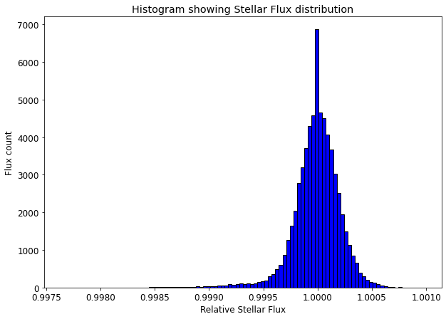

It was decided that if stellar flux < 0.9995 then this will be marked as a transit. A "snapshot" of data was taken each side of the peak, then the modified Gaussian was fit. Additional filtering was carried out to remove false positives. If the transit depths were > 0.0020 then they were removed from the data. This decision was based on knowledge of the 'mean' transit depths from the folded lightcurves. Repeated measurements of the same transit were also removed. Set PLOT=True in the below code block to see every detected transit plotted.

```
Gaussian could not be fitted for transit 71 / 738
Gaussian could not be fitted for transit 146 / 738
Gaussian could not be fitted for transit 213 / 738
Gaussian could not be fitted for transit 222 / 738
Gaussian could not be fitted for transit 248 / 738
Gaussian could not be fitted for transit 283 / 738
Gaussian could not be fitted for transit 484 / 738
Gaussian could not be fitted for transit 614 / 738
```

There is now a list of unsorted transit times. In order to plot the TTVs of each planet, this list will need to be sorted into the three individual exoplanets.

#### 2.9.1 Depth sorting

The first attempt at sorting used the depths of each transit. The distribution of transit depths is show below:

```
There are 634 transits detected.
```

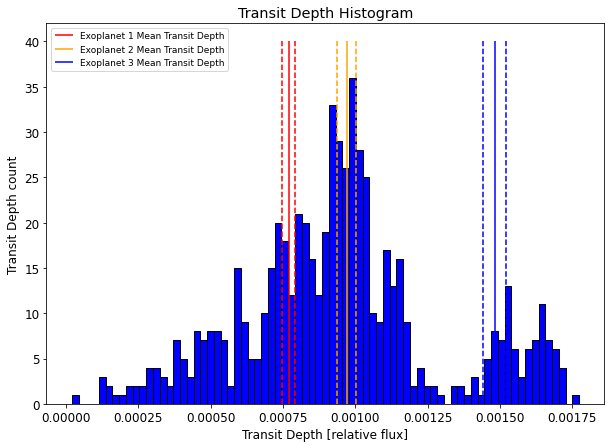

The depths of Exoplanet 1 and 2 are **too convoluted** to distinguish. Exoplanet 3 depths are further away, yet there are less data. An attempt was made to isolate the transits of Exoplanet 3 based on transit depths, but this didn't work and there was cross-contamination. The next attempt to sort the data is shown below:

#### 2.9.2 "Looking ahead" sorting

Next a "looking ahead" method was used to try and sort the different exoplanet transits. This required knowledge of when the first transit of a given exoplanet occured, which was deduced from the phase of the folded lightcurve. The algorithm "looked ahead" by one orbital period ± a tolerance window, and if there was a transit there, it appended it to a new list, and set this transit as the new reference point, then repeated. There are **two problems** with this algorithm:

- It wasn't known with certainty when the first transit occured, as the value deduced from the folded lightcurve didn't match up with a transit in the data, so the closest one was taken.
- The method has a tendancy to "lock on" to the wrong transit data if there are multiple transits in the tolerance window.

The vline plot for Exoplanet 1 is shown below:

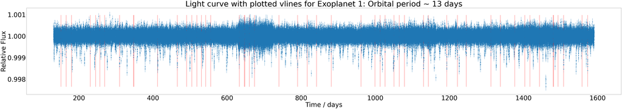

The vlines are irregular, contain gaps and in some cases are too close together. TTVs can't be plotted for data irregularly spaced in this way, so the analysis couldn't be taken further. The main problems were: planets are similar sizes, leading to **similar transit depths**, meaning the data are hard to sort this way.

|  | Planet_1 | Planet_2 | Planet_3 |
| --- | --- | --- | --- |
| Exoplanet Number | [1] | [2] | [3] |
| Orbital Period [days] | [13.024] | [22.687] | [31.996] |
| Orbital Period uncertainty [days] | [0.016] | [0.011] | [0.014] |
| Semi-major Axis [AU] | [0.1083] | [0.1568] | [0.1972] |
| Semi-major Axis [AU] uncertainty | [0.0037] | [0.0053] | [0.0066] |
| Transit depth [relative flux] | [0.000767] | [0.00097] | [0.001482] |
| Transit depth uncertainty [relative flux] | [2.2e-05] | [3.2e-05] | [4e-05] |
| Exoplanet radius [Earth radii] | [3.02] | [3.398] | [4.199] |
| Exoplanet radius uncertainty [Earth radii] | [0.044] | [0.055] | [0.057] |
| Bondi Radius [Earth radii] | [1500.0] | [3880.0] | [4670.0] |
| Upper Bondi radius uncertainty [Earth radii] | [1500.0] | [420.0] | [800.0] |
| Lower Bondi radius uncertainty[ Earth radii] | [800.0] | [800.0] | [1120.0] |
| Mass [Earth masses] | [2.9] | [7.3] | [8.8] |
| Upper Mass [Earth masses] | [5.8] | [8.1] | [10.3] |
| Lower Mass [Earth masses] | [1.3] | [5.8] | [6.7] |
| Density [grams per cubic cm] | [0.58] | [1.02] | [0.65] |
| Upper density uncertainty [grams per cubic cm] | [0.63] | [0.17] | [0.14] |
| Lower density uncertainty [grams per cubic cm] | [0.33] | [0.25] | [0.18] |
| Surface Gravity [g] | [0.32] | [0.63] | [0.5] |
| Upper gravity uncertainty [g] | [0.36] | [0.12] | [0.12] |
| Lower gravity uncertainty [g] | [0.18] | [0.16] | [0.14] |
| Transit duration [hours][theoretical] | [4.27] | [5.14] | [5.76] |
| Transit duration uncertainty [hours][theoretical] | [0.26] | [0.31] | [0.35] |
| Transit duration [hours][graphical] | [5.88] | [6.92] | [5.33] |
| Transit duration uncertainty [hours][graphical] | [0.19] | [0.24] | [0.17] |
| Surface Temperature [K] | [800.0] | [665.0] | [593.0] |
| Surface Temperature uncertainty [K] | [34.0] | [28.0] | [25.0] |

### 3. Discussion

#### 3.1 Discussion of main results.

The above table shows calculated physical properties for each exoplanet. The key points are as follows: all exoplanets are **more massive** than Earth, are **close** to their host star and have **fast** orbital periods.

The exoplanets are visualised below against exoplanets from the NASA exoplanet archive:

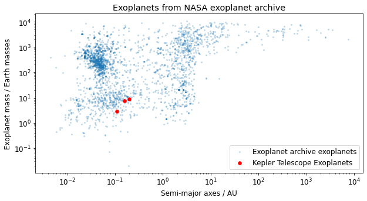

#### 3.2 Selection effects

From the NASA exoplanet archive, it can be seen that the modal exoplanet has a mass of 100 ~ 1000 $M_{\text{earth}}$. These are known as "Hot Jupiters". It's almost impossible to detect exoplanets where semi-major axis $> 10AU$ and $ M_{exo} < M_{\text{earth}}$. These exoplanets are unlikely to be measured by Kepler during a transit. Hence it's possible there are **more exoplanets** present in the system than the 3 detected.

### 3.3 Assessing Habitability of detected exoplanets

#### 3.3.2 Mass densities

Mass densities were calculated as follows:

[output not shown]

The uncertainties are large due to the big uncertainty in each $M_{p}$. The average density of the Earth is $5.513 \text{ g}cm^{-3}$ (NASA, 2023). The density of water is ~ $1 \text{ g}cm^{-3}$. Hence all of these planets are fluid based and **not rocky**.

#### 3.3.3 Bondi radius

A planetary atmosphere is necassary to sustain life to trap heat and insulate against cosmic rays. The Bondi radius of a planet $R_{Bondi}$ determines whether a planet could have accrued an atmosphere during it's formation.

$R_{Bondi} = \frac{G M_p}{c_{sound}^2}$

$R_p$ must be > $R_{Bondi}$ for an atmosphere to form.

The Bondi radii for each planet were calculated as follows:

[output not shown]

It was assumed that $c_{sound} = 343 \text{m}s^-1 $, the speed of sound in air. The uncertainties are once again large due to the big uncertainty in each $M_{p}$. Hence it's **unlikely** that any of the exoplanets accrued and Earth-like atmosphere. They may have atmospheres **less dense** than air.

#### 3.3.4 Surface gravity

The surface gravities were calculated as follows:

| Exoplanet | Surface gravity / $g$ | ± uncertainty / $g$ |
| --- | --- | --- |
| 1 | 0.32 | $^{+0.36}_{-0.18}$ |
| 2 | 0.63 | $^{+0.12}_{-0.16}$ |
| 3 | 0.50 | $^{+0.12}_{-0.14}$ |

If any ET life formed on these planets, it would be capable of evolving to much **larger sizes** than organisms on Earth.

#### 3.3.5 Temperature

Temperature of each exoplanet is a key component of habitability. Assume the host star is Sun-like, meaning effective surface temperature of star $T_{eff_\odot} = 5756 \text{K}$ . Then estimate $T_p \approx T_{eff}\sqrt(\frac{0.9R_{star}}{2a})$ where $T_p$ is the surface temperature of the planet, $R_{star}$ is the star radius and $a$ is the exoplanet's semi-major axis. The albedo of each planet is **not known**. This calculation merely finds the temperature of space at the location of planet. The actual surface temperature of planet < calculated $T_p$ due to reflection.

Surface temperatures were calculated as:

| Exoplanet | Surface temperature / $\text{K}$ | ± uncertainty / $\text{K}$ |
| --- | --- | --- |
| 1 | 800 | 34 |
| 2 | 665 | 28 |
| 3 | 593 | 25 |

Goldilocks zone at which liquid water can exist is $273 \text{K} < T < 373 \text{K}$. Hence it's **unlikely** but **possible** that some of these exoplanets can sustain liquid water. If the planetary albedos are close to 1 then the majority of impinging solar radiation would be reflected, meaning they could be in Goldilocks zone.

#### 3.5 Futher observations

Further observations could include:

- **Polarimetry** measurement, which could give information on atmospheres of exoplanets.
- Analyse **absorption** spectrum, which could help determine potential atmosphere composition.
- **Radial velocity** measurement of star, where long term monitoring could confirm existence of detected exoplanets.
- Additional transit observation for a longer duration could allow TTVs to be plotted.

Other general exoplanet detection methods such as **direct imaging** could also be attempted, although this is unlikely to suceed.

In addition, more knowledge of the system would allow theoretical TTVs to be calculated with TTVFast by Deck et al. (2014).

### 4. Summary

- Flux data from the Kepler Space Telescope of a Sun-like star were analysed.
- The data were reduced to a single lightcurve.
- Periodogram analysis was carried out.
- The light curve was **folded** to each of these potential periods, resulting in the detection of **three** exoplanets.
- Physical properties of each exoplanet were calculated, assuming prior knowledge of the masses of the planets.
- A **second transit detection method** was devised, which used find_peaks() from SciPy.
- Problems were encountered when differentiating planetary transits, as all the exoplanets have similar sizes.
- A second method using a "looking ahead" algorithm was devised, which had limited success in sorting the transits.
- The habitability of each exoplanet was assessed, from which it was concluded that it's **unlikely that any of these exoplanets can harbor life.**
- Further observations opportunities were discussed.

### References:

- Westby & Conselice, 2020 ApJ, 896, 58
- Xie et al. 2018, ApJ, 798, 1538-4357
- Tsevi Mazeh et al. 2013, ApJS, 208, 16
- Katherine M. Deck et al. 2014, ApJ, 787, 132
- Dr. David R. Williams, 2023, nasa.gov website, available at: https://nssdc.gsfc.nasa.gov/planetary/factsheet/earthfact.html

### Acknowledgments:

- NASA exoplanet archive is available at: https://exoplanetarchive.ipac.caltech.edu/index.html
- This investigation would not have been possible without the Python software language. Full documentation is available at: https://www.python.org/
- The author extends their thanks to Carolin Villforth, Steven and Mathilda who provided guidance on this project, and to Vicky Scowcroft, whose light curve folding function was used.

[output not shown]